# Introduction to the NicheMapR ectotherm model

Michael Kearney

2026-04-01

# Overview

This vignette is a tutorial for the NicheMapR ectotherm model (Kearney and Porter, 2019). It only considers the steady state heat and (partial) water budget model. For details on the implementation of the Dynamic Energy Budget model (for simulating growth, development and reproduction as well as full water budgets), see the vignette Introduction to Dynamic Energy Budget models in NicheMapR.

The NicheMapR ectotherm model is run with the function `ectotherm`. It includes a range of morphological, physiological and behavioural options to capture how organisms exchange heat and water with their environments, and to compute the consequences of this for body temperature, activity constraints and different aspects of the mass budget. It is designed to take the output of the NicheMapR microclimate model (Kearney and Porter, 2017) as the driving environmental inputs, but you could construct custom versions of these if desired.

# Basic operation

As with the Introduction to the NicheMapR microclimate model, this first example involves the most basic case of running the model to produce 12 days of output, one for each month of the year (but the model can be run from any outputs from the various microclimate model functions). Try running the model with the default inputs for a location of your choice, e.g.:

```r
library(NicheMapR)
longlat <- c(146.77, -19.29) # Townsville, northern Australia
micro <- micro_global(loc = longlat)
ecto <- ectotherm() # uses default settings (the Eastern Water Skink)
```

The results are returned as a list of tables, here called **ecto**. The main ones to focus on for now are

- **environ** The body temperature, activity and environments experienced by the animal
- **enbal** The components of the computed heat budget
- **masbal** The components of the computed mass budget

# Output table environ

The output table **environ** looks like this (some columns of the first 13 hrs are shown):

| TIME | TC | SHADE | SOLAR | DEP | ACT | TA | TSUB | TSKY | VEL | RELHUM | ZEN | ABSAN |
| --- | --- | --- | --- | --- | --- | --- | --- | --- | --- | --- | --- | --- |
| 0 | 30.45 | 0 | 0.00 | -2.5 | 0 | 30.18 | 30.18 | 30.18 | 0.01 | 99.00 | 90.00 | 0.85 |
| 1 | 29.45 | 0 | 0.00 | -2.5 | 0 | 29.20 | 29.20 | 29.20 | 0.01 | 99.00 | 90.00 | 0.85 |
| 2 | 28.63 | 0 | 0.00 | -2.5 | 0 | 28.39 | 28.39 | 28.39 | 0.01 | 99.00 | 90.00 | 0.85 |
| 3 | 27.96 | 0 | 0.00 | -2.5 | 0 | 27.73 | 27.73 | 27.73 | 0.01 | 99.00 | 90.00 | 0.85 |
| 4 | 27.40 | 0 | 0.00 | -2.5 | 0 | 27.19 | 27.19 | 27.19 | 0.01 | 99.00 | 90.00 | 0.85 |
| 5 | 26.95 | 0 | 0.00 | -2.5 | 0 | 26.75 | 26.75 | 26.75 | 0.01 | 99.00 | 90.00 | 0.85 |
| 6 | 29.84 | 12 | 42.79 | 0.0 | 2 | 24.71 | 25.42 | 16.88 | 0.11 | 79.36 | 83.13 | 0.85 |
| 7 | 29.74 | 48 | 57.33 | 0.0 | 2 | 25.79 | 27.45 | 19.00 | 0.17 | 74.35 | 69.68 | 0.85 |
| 8 | 29.69 | 66 | 42.91 | 0.0 | 2 | 27.03 | 28.90 | 20.87 | 0.24 | 69.57 | 55.98 | 0.85 |
| 9 | 29.88 | 78 | 25.27 | 0.0 | 2 | 28.19 | 29.66 | 22.79 | 0.30 | 66.10 | 42.12 | 0.85 |
| 10 | 29.53 | 90 | 6.33 | 0.0 | 2 | 28.96 | 29.40 | 24.73 | 0.36 | 64.06 | 28.17 | 0.85 |
| 11 | 30.80 | 90 | 7.08 | 0.0 | 2 | 30.24 | 30.74 | 25.94 | 0.42 | 54.38 | 14.20 | 0.85 |
| 12 | 31.65 | 90 | 7.33 | 0.0 | 2 | 31.10 | 31.85 | 26.81 | 0.52 | 54.38 | 1.93 | 0.85 |

| PTCOND | POSTURE | PANT | PCTWET |
| --- | --- | --- | --- |
| 10 | 0 | 1 | 0.1 |
| 10 | 0 | 1 | 0.1 |
| 10 | 0 | 1 | 0.1 |
| 10 | 0 | 1 | 0.1 |
| 10 | 0 | 1 | 0.1 |
| 10 | 0 | 1 | 0.1 |
| 10 | 0 | 1 | 0.1 |
| 10 | 0 | 1 | 0.1 |
| 10 | 0 | 1 | 0.1 |
| 10 | 0 | 1 | 0.1 |
| 10 | 0 | 1 | 0.1 |
| 10 | 0 | 1 | 0.1 |
| 10 | 0 | 1 | 0.1 |

and includes the following variables (among others):

- **TIME** - time of day (hours)
- **TC** - body temperature (°C)
- **SHADE** - shade selected (%)
- **SOLAR** - solar radiation (W/m2) at animal location
- **DEP** - depth below ground (cm)
- **ACT** - activity state (0=inactive, 1=basking, 2=foraging)
- **TA** - air temperature (°C) at animal location
- **TSUB** - substrate temperature (°C) at animal location
- **TSKY** - overhead (sky) temperature (°C) at animal location
- **VEL** - wind speed (m/s) at animal location
- **RELHUM** - relative humidity (%) at animal location
- **ZEN** - zenith angle of sun (degrees, where 90° = below the horizon)
- **ABSAN** - solar absorptivity (fractional)
- **PCOND** - proportion of animal’s surface in contact with ground (fractional)
- **POSTURE** - postural orientation (1=perpendicular to sun, 2=parallel, 0=in-between)
- **PANT** - panting multiplier (>1 means panting)
- **PCTWET** - percent of the skin that is wet (0-100%)

The model has considered, for each hour of the day, where the organism could be in its habitat conditional on the behavioural options set. The default simulation is for the Eastern Water Skink, *Eulamprus quoyii*, which is diurnal (`diurn = 1`, `nocturn = 0`, `crepus = 0`). So, for the nighttime and twilight hours, the animal is assumed to be underground (`burrow = 1`).

The algorithm choosing the depth at which to put the animal starts at the shallowest depth allowed (here node 2 which is 2.5 cm, but it could be node 1 which is the surface) and moves deeper only if it would go below the stated critical thermal minimum `CT_min` (6 °C by default) or if it would be more than half way between the maximum foraging temperature `T_F_max` (34 °C by default) and the critical thermal maximum `CT_max` (40 °C by default).

Note how the wind speed is set to an arbitrarily low value when then animal is sheltering under ground, and the air, substrate and ‘sky’ temperatures are equal to the soil temperature at the chosen depth.

When the sun rises (**ZEN** < 90°, at 6 am in in this case) the model tries placing the animal on the surface in the open, as long as the animal’s body temperature is above the emergence temperature `T_RB_min` (i.e. retreat to basking transition, which is 17.5 °C by default). If the resulting computed body temperature is above the minimum basking threshold `T_B_min` (also 17.5 °C by default), that becomes the selected environment and the activity state **ACT** is reported as 1.

If the body temperature is above the minimum foraging temperature `T_F_min`, then activity state is set to 2. If the animal’s predicted temperature is above the preferred temperature `T_pref` (30 °C by default), then the animal changes posture to be parallel to the sun’s rays and thereby minimise solar heat gain. If this prevents the `T_pref` from being exceeded then the animal is recorded to be in this posture.

Once the maximum shade is reached, the animal’s preferred temperature is allowed to rise in 0.5 degree increments until the maximum foraging temperature is reached `T_F_max`, upon which the animal is forced to become inactive.

The animal may also change its posture when cold to point normal to the sun (**postur** = 1) and potentially increase the contact with the substrate (**pcond** will increase by 20%) if the ground is warmer than the body. These postural adjustments aren’t necessary in this particular simulation, but can be important under cooler climates.

# Output table enbal

The output table **enbal** looks like this:

| DOY | YEAR | DAY | TIME | QSOL | QIRIN | QMET | QRESP | QEVAP | QIROUT | QCONV | QCOND | ENB | NTRY |
| --- | --- | --- | --- | --- | --- | --- | --- | --- | --- | --- | --- | --- | --- |
| 15 | 1 | 1 | 0 | 0.00 | 4.59 | 0.02 | 0 | 0.00 | 4.60 | 0.01 | 0 | 0 | 1 |
| 15 | 1 | 1 | 1 | 0.00 | 4.53 | 0.02 | 0 | 0.00 | 4.54 | 0.01 | 0 | 0 | 1 |
| 15 | 1 | 1 | 2 | 0.00 | 4.48 | 0.02 | 0 | 0.00 | 4.50 | 0.01 | 0 | 0 | 1 |
| 15 | 1 | 1 | 3 | 0.00 | 4.44 | 0.02 | 0 | 0.00 | 4.46 | 0.01 | 0 | 0 | 1 |
| 15 | 1 | 1 | 4 | 0.00 | 4.41 | 0.02 | 0 | 0.00 | 4.42 | 0.01 | 0 | 0 | 1 |
| 15 | 1 | 1 | 5 | 0.00 | 4.39 | 0.01 | 0 | 0.00 | 4.40 | 0.01 | 0 | 0 | 1 |
| 15 | 1 | 1 | 6 | 0.95 | 4.06 | 0.02 | 0 | 0.00 | 4.57 | 0.46 | 0 | 0 | 5 |
| 15 | 1 | 1 | 7 | 0.82 | 4.18 | 0.02 | 0 | 0.00 | 4.56 | 0.45 | 0 | 0 | 17 |
| 15 | 1 | 1 | 8 | 0.63 | 4.27 | 0.02 | 0 | 0.00 | 4.56 | 0.36 | 0 | 0 | 23 |
| 15 | 1 | 1 | 9 | 0.46 | 4.35 | 0.02 | 0 | 0.01 | 4.57 | 0.26 | 0 | 0 | 27 |
| 15 | 1 | 1 | 10 | 0.23 | 4.40 | 0.02 | 0 | 0.01 | 4.55 | 0.09 | 0 | 0 | 31 |
| 15 | 1 | 1 | 11 | 0.24 | 4.47 | 0.02 | 0 | 0.01 | 4.63 | 0.10 | 0 | 0 | 33 |
| 15 | 1 | 1 | 12 | 0.24 | 4.53 | 0.02 | 0 | 0.01 | 4.68 | 0.11 | 0 | 0 | 35 |

It quantifies the different pathways of exchange in each hour of the simulation:

- **DOY** - day of year
- **YEAR** - year of simulation
- **DAY** - day of simulation
- **TIME** - time of day (hours)
- **TC** - body temperature (°C)
- **QSOL** - solar radiation absorbed (W)
- **QIRIN** - infrared radiation absorbed (W)
- **QMET** - metabolic heat production (W)
- **QEVAP** - evaporative heat loss (W)
- **QIROUT** - infrared radiation lost (W)
- **QCONV** - heat lost by convection (W)
- **QCOND** - heat lost by conduction (W)
- **ENB** - energy balance (°C)
- **NTRY** - iterations required for solution to heat balance equation

where the complete heat budget is

$$ENB = QSOL + QIRIN + QMET - QEVAP -
QIROUT - QCONV - QCOND$$

# Output table masbal

Finally, the table **masbal** includes the following outputs (among others):

| DOY | YEAR | DAY | TIME | O2_ml | H2OResp_g | H2OCut_g | H2OEye_g |
| --- | --- | --- | --- | --- | --- | --- | --- |
| 15 | 1 | 1 | 0 | 3.570550 | 0.0000554 | 0.0000571 | 0.0000000 |
| 15 | 1 | 1 | 1 | 3.269973 | 0.0000447 | 0.0000506 | 0.0000000 |
| 15 | 1 | 1 | 2 | 3.044180 | 0.0000375 | 0.0000459 | 0.0000000 |
| 15 | 1 | 1 | 3 | 2.870615 | 0.0000324 | 0.0000424 | 0.0000000 |
| 15 | 1 | 1 | 4 | 2.734902 | 0.0000288 | 0.0000397 | 0.0000000 |
| 15 | 1 | 1 | 5 | 2.628471 | 0.0000261 | 0.0000377 | 0.0000000 |
| 15 | 1 | 1 | 6 | 3.385772 | 0.0011651 | 0.0036813 | 0.0012275 |
| 15 | 1 | 1 | 7 | 3.355653 | 0.0011387 | 0.0046652 | 0.0015556 |
| 15 | 1 | 1 | 8 | 3.340857 | 0.0011153 | 0.0055233 | 0.0018417 |
| 15 | 1 | 1 | 9 | 3.397453 | 0.0011372 | 0.0063483 | 0.0021168 |
| 15 | 1 | 1 | 10 | 3.293222 | 0.0010226 | 0.0065877 | 0.0021966 |
| 15 | 1 | 1 | 11 | 3.682710 | 0.0015418 | 0.0096732 | 0.0032255 |

- **DOY** - day of year
- **YEAR** - year of simulation
- **DAY** - day of simulation
- **TIME** - time of day (hours)
- **O2_ml** - oxygen consumption rate (ml/h)
- **H2OResp_g** - respiratory water loss (g/h)
- **H2OCut_g** - cutaneous water loss (g/h)
- **H2OEye_g** - ocular water loss (g/h)

There are a number of other columns in this output but they are of value zero because we are not running the Dynamic Energy Budget model (i.e. `DEB = 0` by default). We are instead obtaining the oxygen consumption rate (ml/h) by an allometric function based on Eq. 2 from Andrews & Pough 1985,

$V_{O_2} = M_1 M^{M_2} 10^{M_3 T_b}$

From the percentage of the skin that is ‘wet’ `pct_wet` one can estimate the cutaneous water loss **H2O_cut**. The `pct_wet` parameter represents the % surface area that would act as free water surface if all the little pores letting water through the skin were collected together in one place.

Finally, the parameter `pct_eyes` is the % of the total surface area taken up by the eyes when open, and is used to compute ocular water loss when the animal is active (this can be a substantial part of the water loss).

If you are interested in the other quantities available in the **masbal** output, you will need to develop a DEB model for your species (see the [Dynamic Energy Budget lab](http://www.bio.vu.nl/thb/deb/deblab/), particularly the [Add-my-pet Portal](http://www.bio.vu.nl/thb/deb/deblab/add_my_pet/), for details, as well as the vignette Introduction to Dynamic Energy Budget models in NicheMapR which explains the **debout** output table).

# Plotting some output

Now let’s take broader look at the simulation outcome, by plotting the results. We will this time be explicit about the parameter values as follows (see the help for the ectotherm model by typing ?ectotherm in the R console to get more details on the options for these and other parameters):

```r
Ww_g <- 40        # wet weight of animal (g)
pct_wet <- 0.2    # % of surface area acting as a free-water exchanger
alpha_min <-0.85  # minimum solar absorbtivity (dec %)
alpha_max <- 0.85 # maximum solar absorbtivity (dec %)
shape <- 3        # lizard shape
T_RB_min <- 17.5  # min Tb at which they will attempt to leave retreat
T_B_min <- 17.5   # min Tb at which leaves retreat to bask
T_F_min <- 24     # minimum Tb at which activity occurs
T_F_max <- 34     # maximum Tb at which activity occurs
T_pref <- 30      # preferred Tb (will try and regulate to this)
CT_max <- 40      # critical thermal minimum (affects choice of retreat)
CT_min <- 6       # critical thermal maximum (affects choice of retreat)
mindepth <- 2     # min depth (node, 1-10) allowed
maxdepth <- 10    # max depth (node, 1-10) allowed
shade_seek <- 1   # shade seeking?
burrow <- 1       # can it burrow?
climb <- 0        # can it climb to thermoregulate?
nocturn <- 0      # nocturnal activity
crepus <- 0       # crepuscular activity
diurn <- 1        # diurnal activity
minshades <- rep(0, 12 * 24)   # min available shade?
maxshades <- rep(micro$maxshade, each = 24) # max available shade?
```

Run the ectotherm model, retrieve the output and create some mock dates.

```r
ecto <- ectotherm(Ww_g = Ww_g, alpha_max = alpha_max, alpha_min = alpha_min, shape = shape, pct_wet = pct_wet, T_F_max = T_F_max, T_F_min = T_F_min, T_B_min = T_B_min, T_RB_min = T_RB_min, CT_max = CT_max, CT_min = CT_min, T_pref = T_pref, mindepth = mindepth, maxdepth = maxdepth, shade_seek = shade_seek, burrow = burrow, climb = climb, minshades = minshades, nocturn = nocturn, diurn = diurn, crepus = crepus, maxshades = maxshades)

# retrieve output
environ <- as.data.frame(ecto$environ) # behaviour, Tb and environment
enbal <- as.data.frame(ecto$enbal) # heat balance outputs
masbal <- as.data.frame(ecto$masbal) # mass balance outputs
metout <- as.data.frame(micro$metout) # above ground microclimate
environ <- cbind(environ,metout$SOLR) # add solar radiation for activity window plots
colnames(environ)[ncol(environ)] <- "Solar"

# append dates
days <- rep(seq(1,12),24)
days <- days[order(days)]
dates <- days+metout$TIME/60/24-1 # dates for hourly output
dates2 <- seq(1,12,1) # dates for daily output
metout <- cbind(dates,metout)
environ <- cbind(dates,environ)
masbal <- cbind(dates,masbal)
enbal <- cbind(dates,enbal)
```

Plot the body temperature, shade, activity and depth selected through time.

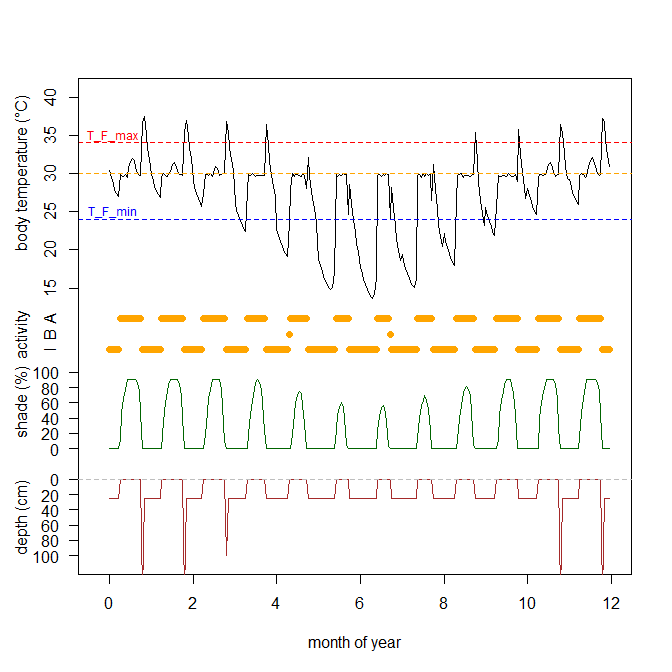

**Body temperature, depth, shade and activity of for the lizard *Eulamprus quoyii* with shade options ranging from 0% to 90%**

```r
with(environ, plot(TC ~ dates, ylab = "", xlab="month of year", col = 'black', xlim = c(-0.25, 12), ylim = c(-20, 40), type = "l", yaxt = 'n'))
with(environ, points(ACT * 2 + 7 ~ dates, type = "p", pch = 16, col = "orange"))
with(environ, points(SHADE / 10 - 6 ~ dates, type = "l", col = "dark green"))
with(environ, points(DEP - 10 ~ dates, type = "l", col = "brown"))
abline(ecto$T_F_min, 0, lty = 2, col = 'blue')
abline(T_pref, 0, lty = 2, col = 'orange')
abline(ecto$T_F_max, 0, lty = 2, col = 'red')
ytick<-seq(15, 40, by=5)
axis(side=2, at=ytick, labels = TRUE)
mtext(text = c('A', 'B', 'I'), side = 2, line = 1, at = c(11, 9, 7))
ytick<-seq(-6, 4, by=2)
axis(side=2, at=ytick, labels = FALSE)
mtext(text = seq(0, 100, 20), side = 2, line = 1, at = seq(-6, 4, 2), las = 2)
ytick<-seq(-20, -10, by=2)
axis(side=2, at=ytick, labels = FALSE)
mtext(text = rev(seq(0, 100, 20)), side = 2, line = 1, at = seq(-20, -10, 2), las = 2)
abline(h = -10, lty = 2, col = 'grey')
mtext(text = c('body temperature (°C)', 'activity', 'shade (%)', 'depth (cm)'), side = 2, line = 2.5, at = c(30, 9, 0, -15))
text(0.1, c(ecto$T_F_max + 1, ecto$T_F_min + 1), c('T_F_max', 'T_F_min'), col = c('red', 'blue'), cex = 0.75)
```

Note how this lizard is active every day, but requires shade for this, and how body temperature jumps up on some evenings when it goes into its burrow (remember when inactive the body temperature may rise to a maximum of half way between `T_F_max` and `CT_max` before the animal moves deeper into the burrow).

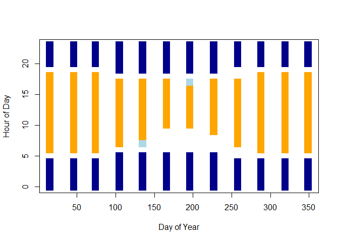

**Annual activity window for the lizard *Eulamprus quoyii* with shade options ranging from 0% to 90%**

```r
# seasonal activity plot (dark blue = night, light blue = basking, orange = foraging)
forage <- subset(environ, ACT == 2) # get foraging hours
bask <- subset(environ, ACT == 1) # get basking hours
night <- subset(environ, Solar == 0) # get night hours
with(night, plot(TIME ~ DOY, ylab = "Hour of Day", xlab = "Day of Year", pch = 15, cex = 2,
                 col = 'dark blue')) # nighttime hours
with(forage, points(TIME ~ DOY, pch = 15, cex = 2, col = 'orange')) # foraging Tbs
with(bask, points(TIME ~ DOY, pch = 15, cex = 2, col = 'light blue')) # basking Tbs
```

In Figure 2 you can see the annual activity window, with dark blue representing the nighttime hours, light blue the basking hours and orange the foraging hours. Activity is possible for this lizard at this tropical location throughout they year.

Explore what changing the thermal thresholds `CT_min`, `T_RB_min`, `T_B_min`, `T_F_min`, `T_F_max` and `CT_max` does to these plots, as well as variation in available shade `maxshades` and burrow depths `mindepth` and `maxdepth`. Here is an example of the effect of reducing maximum shade in all months from 90% to 10%:

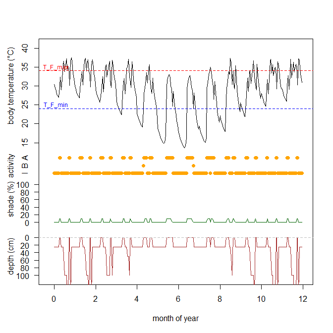

**Body temperature, depth, shade and activity of for the lizard *Eulamprus quoyii* with shade options ranging from 0% to 10%**

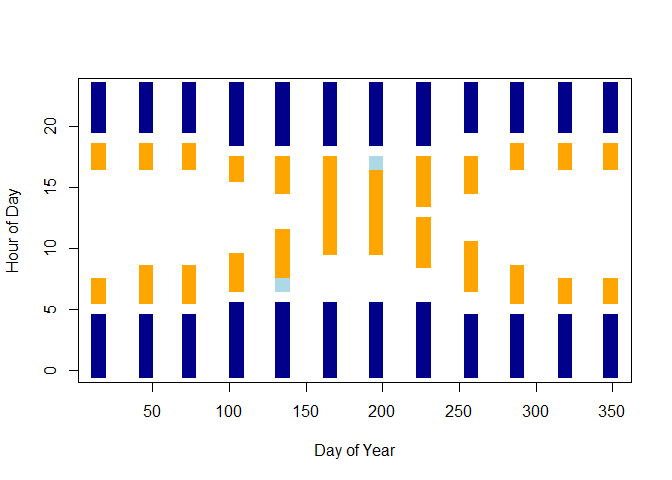

**Annual activity window for the lizard *Eulamprus quoyii* with shade options ranging from 0% to 10%**

```r
forage<-subset(environ,ACT==2)
bask<-subset(environ,ACT==1)
night<-subset(environ,Solar==0)
day<-subset(environ,Solar==0)
with(night,plot(TIME ~ DOY,ylab="Hour of Day",xlab="Day of Year",pch=15,cex=2,col=
    'dark blue'))
# nighttime hours
with(forage,points(TIME~DOY,pch=15,cex=2,col='orange')) # foraging Tbs
with(bask,points(TIME~DOY,pch=15,cex=2,col='light blue')) # basking Tbs
```

# Discussion

The capacity to compute body temperature, metabolic rates, activity times and some aspects of the water budget under realistic microclimates allows many inferences to be made about the ability of different types of animals to live in different climates and habitats. In some cases such processes may be limiting factors of the distribution. For example, Kearney and Porter (2004) found that activity time was likely to be a limiting factor for a nocturnal lizard in southern Australia. More often, these constraints act to limit the overall energy and water budget in a more subtle manner.

The preliminary computations made in this tutorial can provide the starting point for an energy and mass budget analysis that could ultimately allow you to predict reproductive success and survival rates, the ‘vital rates’ that link individuals to populations.

One of the most powerful ways of achieving a full mass balance and life cycle trajectory is by using the Dynamic Energy Budget (DEB) theory and its associated models (Kooijman, 2010). DEB theory integrated into the NicheMapR package as described further in the vignette Introduction to Dynamic Energy Budget models in NicheMapR.

Below is an example of the sort of calculation that can be made with the integration of DEB theory and the ectotherm model - a simulation of the Australian Water Skink, *Eulamprus quoyii* growing at Townsville Australia (see Schwarzkopf et al. 2016). This example is explained further in the DEB vignette just mentioned.

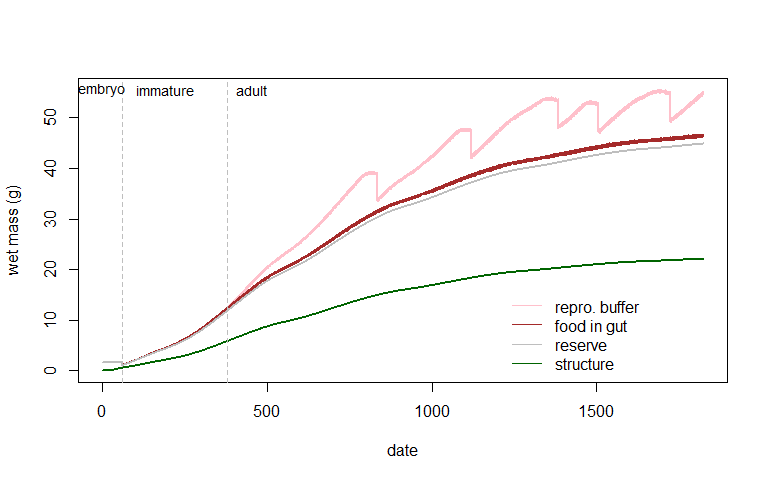

# References

Andrews, R. M., and H. F. Pough. 1985. Metabolism of squamate reptiles: allometric and ecological relationships. Physiological Zoology 58:214-231.

Kearney, M., and W. P. Porter. 2004. Mapping the fundamental niche: physiology, climate, and the distribution of a nocturnal lizard. Ecology 85:3119-3131.

Kearney, M. R., & Porter, W. P. (2017). NicheMapR - an R package for biophysical modelling: the microclimate model. Ecography, 40(5), 664–674. doi:10.1111/ecog.02360

Kearney, M. R., & Porter, W. P. (2019). NicheMapR - an R package for biophysical modelling: the ectotherm and Dynamic Energy Budget models. Ecography. doi:10.1111/ecog.04680

Kooijman, S. A. L. M. 2010. Dynamic Energy Budget Theory for Metabolic Organisation. Cambridge University Press, Great Britain.

Schwarzkopf, L., M. J. Caley, and M. R. Kearney. 2016. One lump or two? Explaining a major latitudinal transition in reproductive allocation in a viviparous lizard. Functional Ecology. DOI: 10.1111/1365-2435.12622